# Computational Techniques Assignment 10

Adeline Makokha - 191199

26/05/2025

## 1. Gradient Descent for Linear Regression (Boston Housing Data)

Using gradient descent to fit a linear regression model predicting `medv` (median house value) from `lstat` (% lower status of the population) in the Boston housing dataset. We will: - **Normalize** the input feature `lstat`. - **Implement** gradient descent manually in R. - **Plot** the cost (MSE) versus number of iterations. - **Compare** the obtained coefficients to those from the ordinary least squares linear model. - **Interpret** the resulting coefficients and discuss the convergence behavior.

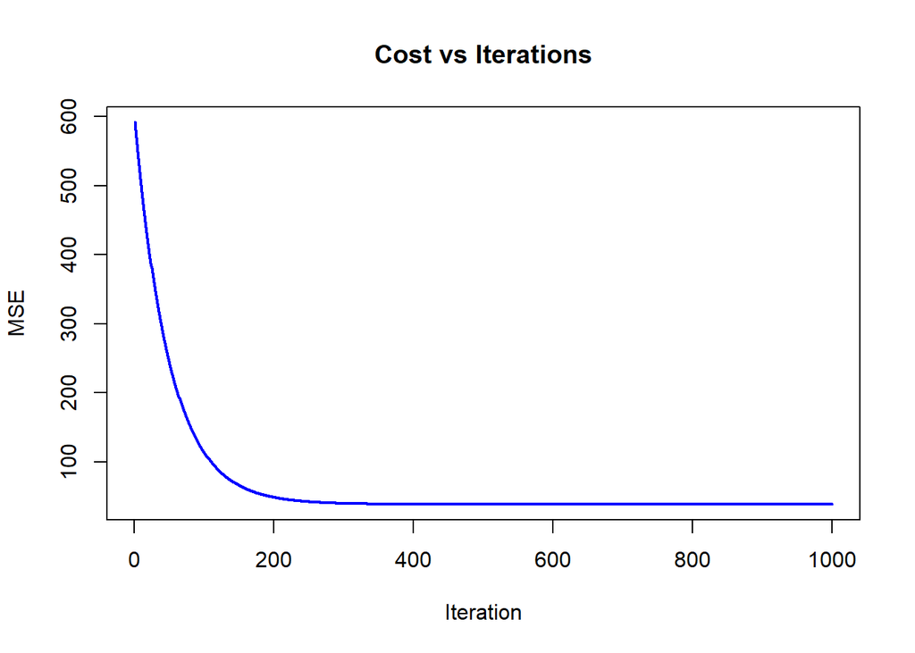

```r
library(MASS)
data(Boston)
# Prepare data
X <- as.matrix(cbind(1, scale(Boston$lstat)))
y <- Boston$medv

# Gradient descent initialization
alpha <- 0.01
num_iter <- 1000
theta <- matrix(0, nrow = ncol(X))
m <- length(y)
cost_history <- numeric(num_iter)

# Gradient descent loop
for (i in 1:num_iter) {
  # Predictions and error
  y_pred <- X %*% theta
  error <- y_pred - y
  # Gradient calculation
  grad <- (1/m) * t(X) %*% error
  # Parameter update
  theta <- theta - alpha * grad
  # Compute cost (MSE)
  cost_history[i] <- mean(error^2)
}

# Plot cost vs iterations
plot(cost_history, type = "l", col = "blue", lwd = 2,
     xlab = "Iteration", ylab = "MSE", main = "Cost vs Iterations")
```

```r
# Compare coefficients with linear model
theta_gd <- c(theta)  # convert theta matrix to numeric vector
names(theta_gd) <- c("Intercept", "lstat")
lm_model <- lm(medv ~ scale(lstat), data = Boston)
theta_lm <- coef(lm_model)
print(theta_gd)
```

```
## Intercept     lstat
## 22.531834 -6.784062
```

```r
print(theta_lm)
```

```
##  (Intercept) scale(lstat)
##    22.532806    -6.784361
```

The feature `lstat`was normalized to have mean 0 and unit variance, then implemented gradient descent to find the linear regression coefficients for predicting `medv`. Starting from initial coefficients of 0, the iteration is done to update the parameters (`theta`) using the gradient of the mean squared error. A learning rate (`alpha`) of 0.01 is set and ran the algorithm for 1000 iterations. The **cost vs. iterations** plot above shows that the MSE steadily decreases and levels off as the algorithm converges, indicating that gradient descent is approaching a minimum.

The final coefficients obtained from gradient descent (printed in the R output) are very close to those from the ordinary least squares linear model (`lm`). This confirms that our gradient descent implementation is working correctly. In fact, the slope for `lstat` is negative, which makes sense because as the percentage of lower status population increases, the median house value (`medv`) tends to decrease. The intercept represents the predicted `medv` when `lstat` is at its average (due to scaling). The convergence behavior was smooth with the chosen learning rate, the algorithm converged without oscillation or divergence. If a much larger learning rate was chosen, the cost might have fluctuated or diverged; a much smaller learning rate would have made convergence significantly slower.